# time series analysis in R

**Testing whether an object is a time series**

When you use datasets from others, such as those included in an R package, you can check whether they are `ts` objects using the **is.ts()** command. The result of the test is either `TRUE` when the data is of the `ts` class, or `FALSE` if it is not.

In this exercise, you’ll explore the class of the datasets you’ve been using throughout this chapter.

[output not shown]

```r
# Check whether Nile is a ts object
is.ts(Nile)
```

```
## [1] TRUE
```

```r
# Check whether AirPassengers is a ts object
is.ts(AirPassengers)
```

```
## [1] TRUE
```

`is.ts()` is a simple command for determining whether or not you’re working with a `ts` object. As you can see, the `Nile` and `AirPassengers` datasets you worked with earlier in the chapter are both encoded as `ts` objects.

**Plotting a time series object**

It is often very useful to plot data we are analyzing, as is the case when conducting time series analysis. If the dataset under study is of the `ts` class, then the `plot()` function has methods that automatically incorporate time index information into a figure.

Let’s consider the `eu_stocks` dataset (available in R by default as `EuStockMarkets`). This dataset contains daily closing prices of major European stock indices from 1991-1998, specifically, from Germany (`DAX`), Switzerland (`SMI`), France (`CAC`), and the UK (`FTSE`). The data were observed when the markets were open, so there are no observations on weekends and holidays. We will proceed with the approximation that this dataset has evenly spaced observations and is a four dimensional time series.

To conclude this chapter, this exercise asks you to apply several of the functions you’ve already learned to this new dataset.

```r
eu_stocks <- EuStockMarkets

# Check whether eu_stocks is a ts object
is.ts(eu_stocks)
```

```
## [1] TRUE
```

```r
# View the start, end, and frequency of eu_stocks
start(eu_stocks)
```

```
## [1] 1991  130
```

```r
end(eu_stocks)
```

```
## [1] 1998  169
```

```r
frequency(eu_stocks)
```

```
## [1] 260
```

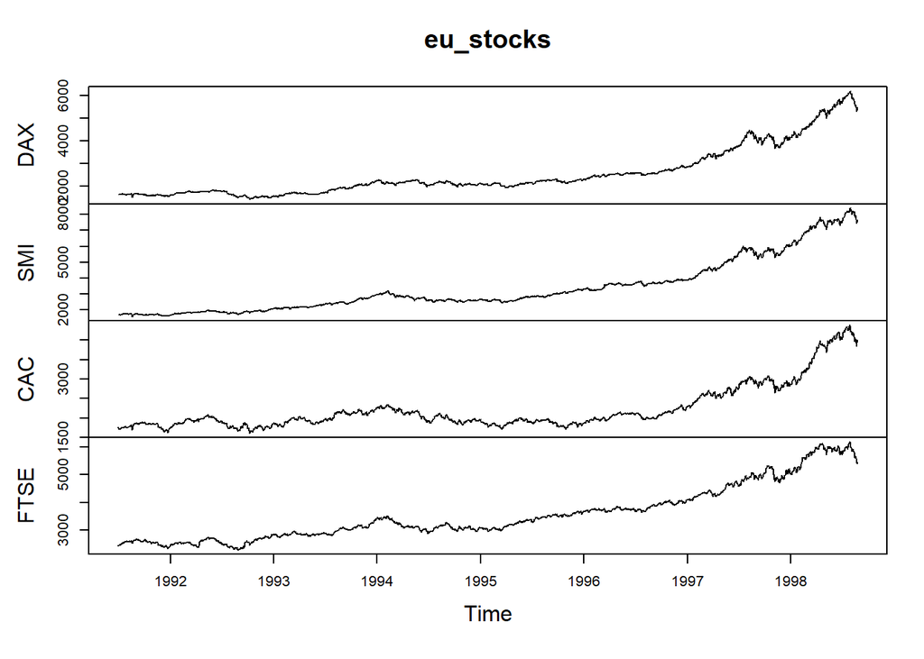

```r
# Generate a simple plot of eu_stocks
plot(eu_stocks)
```

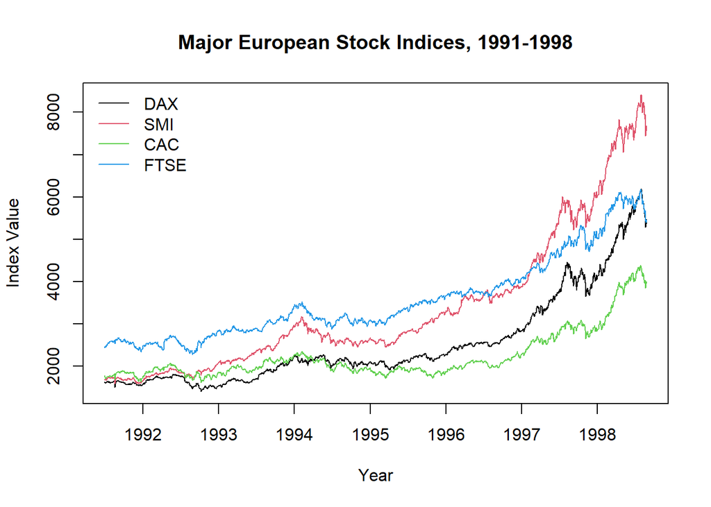

```r
# Use ts.plot with eu_stocks
ts.plot(eu_stocks, col = 1:4, xlab = "Year", ylab = "Index Value", main = "Major European Stock Indices, 1991-1998")

# Add a legend to your ts.plot
legend("topleft", colnames(eu_stocks), lty = 1, col = 1:4, bty = "n")
```

You’ve mastered the basics of the `ts` class in R, including encoding `ts` objects, viewing basic time series qualities, and plotting time series data. Now let’s move on to the next chapter!

**Trend spotting!**

- some data do not have trends
- linear
  - positive/negative autocorrelation
- rapid growth/decay
- periodic
- variance
- Sample transformations
  - `log()` can linearize a rapid (either values or variance) growth trend
  - `diff()` can remove a linear trend
  - `diff(..., s)` can remove periodic trends

**Removing trends in variability via the logarithmic transformation**

The logarithmic function `log()` is a data transformation that can be applied to positively valued time series data. It slightly shrinks observations that are greater than one towards zero, while greatly shrinking very large observations. This property can stabilize variability when a series exhibits increasing variability over time. It may also be used to linearize a rapid growth pattern over time.

The time series `rapid_growth` has already been loaded, and is shown in the figure below. Note the vertical range of the data.

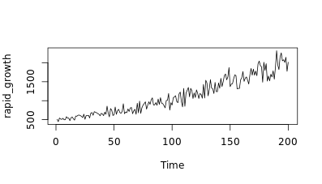

6.png

```
# Log rapid_growth
linear_growth <- log(rapid_growth)

# Plot linear_growth using ts.plot()
ts.plot(linear_growth)
```

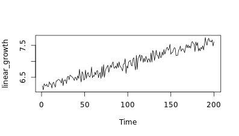

7.png

As you can see, the logarithmic transformation helps stabilize your data by inducing linear growth over time. Remember to adjust your *interpetation* of the data accordingly.

**Removing trends in level by differencing**

The first difference transformation of a time series $z_t$ consists of the differences (changes) between successive observations over time, that is $z_t−z_{t−1}$.

Differencing a time series can remove a time trend. The function **diff()** will calculate the first difference or change series. A difference series lets you examine the increments or changes in a given time series. It always has one fewer observations than the original series.

The time series `z` has already been loaded, and is shown in the figure below.

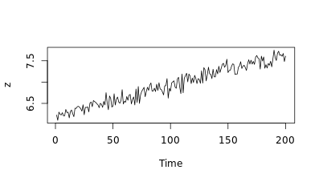

8.png

```
# Generate the first difference of z
dz <- diff(z)

# Plot dz
ts.plot(dz)

# View the length of z and dz, respectively
length(z)
######################################################
[1] 200
######################################################

length(dz)
######################################################
[1] 199
######################################################
```

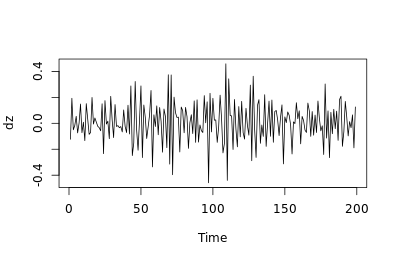

9.png

By removing the long-term time trend, you can view the amount of change from one observation to the next.

**Removing seasonal trends with seasonal differencing**

For time series exhibiting seasonal trends, seasonal differencing can be applied to remove these periodic patterns. For example, monthly data may exhibit a strong twelve month pattern. In such situations, changes in behavior from year to year may be of more interest than changes from month to month, which may largely follow the overall seasonal pattern.

The function `diff(..., lag = s)` will calculate the lag `s` difference or length `s` seasonal change series. For monthly or quarterly data, an appropriate value of `s` would be 12 or 4, respectively. The `diff()` function has `lag = 1` as its default for first differencing. Similar to before, a seasonally differenced series will have `s` fewer observations than the original series.

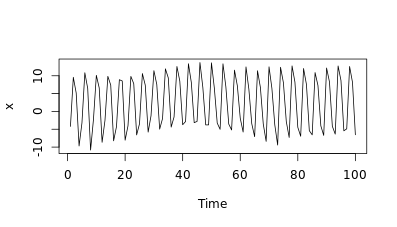

10.png

```
# Generate a diff of x with n = 4. Save this to dx
dx <- diff(x, lag = 4)

# Plot dx
ts.plot(dx)

# View the length of x and dx, respectively
length(x)
######################################################
[1] 100
######################################################

length(dx)
######################################################
[1] 96
######################################################
```

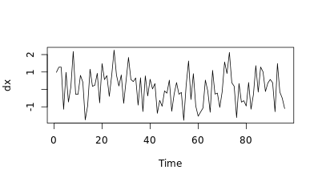

11.png

Once again differencing allows you to remove the longer-term time trend - in this case, seasonal volatility - and focus on the change from one period to another.

**The white noise (WN) model**

- White noise
  - the simplest example of a stationary process
- a *weak* white noise process has:
  - a fixed, constant mean
  - a fixed, constant variance
  - no correlation over time

**Simulate the white noise model**

The white noise (WN) model is a basic time series model. It is also a basis for the more elaborate models we will consider. We will focus on the simplest form of WN, independent and identically distributed data.

The [arima.sim()](https://www.rdocumentation.org/packages/stats/versions/3.3.1/topics/arima.sim) function can be used to simulate data from a variety of time series models. ARIMA is an abbreviation for the autoregressive integrated moving average class of models we will consider throughout this course.

An **ARIMA(p, d, q)** model has three parts, the autoregressive order `p`, the order of integration (or differencing) `d`, and the moving average order `q`. We will detail each of these parts soon, but for now we note that the **ARIMA(0, 0, 0)** model, i.e., with all of these components zero, is simply the WN model.

In this exercise, you will practice simulating a basic WN model.

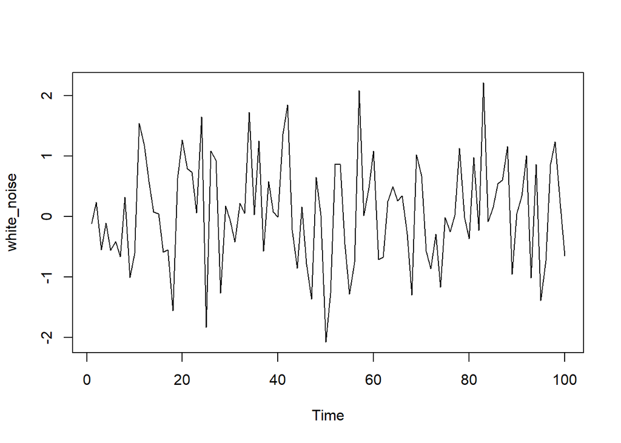

```r
# Simulate a WN model with list(order = c(0, 0, 0))
white_noise<- arima.sim(model = list(order = c(0, 0, 0)), n = 100)

# Plot the WN observations
ts.plot(white_noise)
```

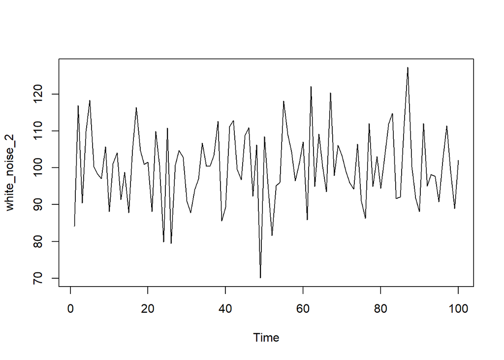

```r
# Simulate from the WN model with: mean = 100, sd = 10
white_noise_2 <- arima.sim(list(order = c(0, 0, 0)), n = 100, mean = 100, sd = 10)

# Plot your white_noise_2 data
ts.plot(white_noise_2)
```

The `arima.sim()` command is a useful way to quickly simulate time series data with the qualities you specify.

**Estimate the white noise model**

For a given time series `y` we can fit the white noise (WN) model using the `arima(..., order = c(0, 0, 0))` function. Recall that the WN model is an ARIMA(0,0,0) model. Applying the **arima()** function returns information or output about the estimated model. For the WN model this includes the estimated mean, labeled `intercept`, and the estimated variance, labeled `sigma^2`.

In this exercise, you’ll explore the qualities of the WN model. What is the estimated mean? Compare this with the sample mean using the mean() function. What is the estimated variance? Compare this with the sample variance using the **var()** function.

The time series y has already been loaded, and is shown in the adjoining figure.

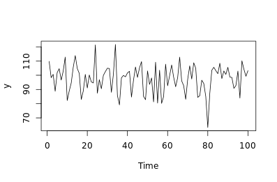

12.png

```
# Fit the WN model to y using the arima command
arima(y, order = c(0, 0, 0))

######################################################
Call:
arima(x = y, order = c(0, 0, 0))

Coefficients:
      intercept
        97.5428
s.e.     0.9697

sigma^2 estimated as 94.03:  log likelihood = -369.08,  aic = 742.15
######################################################

# Calculate the sample mean and sample variance of y
mean(y)
######################################################
[1] 97.54284
######################################################

var(y)
######################################################
[1] 94.98175
######################################################
```

From the comparisons you can see that the `arima()` function estimates are very close to the sample mean and variance estimates, in fact identical for the mean.

**The random walk (RW) model**

- Random walk (RW) is a simple example of a non-stationary process
- A random walk has:
  - no specified mean or variance
  - strong dependence over time
  - its changes or increments are white noise (WN)
- The random walk recursion:
  - $Today = Yesterday + Noise$
  - $Y_t = Y_{t-1} + \epsilon_t$
    - where $\epsilon_t$ is mean zero white noise (WN)
  - simulation requires an initial point $Y_0$
  - only one parameter, the WN variance $\sigma^2_\epsilon$
  - as $Y_t - Y_{t-1} = \epsilon_t$ -> `diff(Y)` is WN
- Random walk with a drift
  - $Today = Constant + Yesterday + Noise$
  - $Y_t = c + Y_{t-1} + \epsilon_t$
  - two parameters, the constant $c$, and the WN variance $\sigma^2_\epsilon$
  - $Y_t - Y_{t-1} = ?$ -> WN with mean $c$

**Simulate the random walk model**

The random walk (RW) model is also a basic time series model. It is the cumulative sum (or integration) of a mean zero white noise (WN) series, such that the first difference series of a RW is a WN series. Note for reference that the RW model is an **ARIMA(0, 1, 0)** model, in which the middle entry of 1 indicates that the model’s order of integration is 1.

The `arima.sim()` function can be used to simulate data from the RW by including the `model = list(order = c(0, 1, 0))` argument. We also need to specify a series length `n`. Finally, you can specify a `sd` for the series (increments), where the default value is 1.

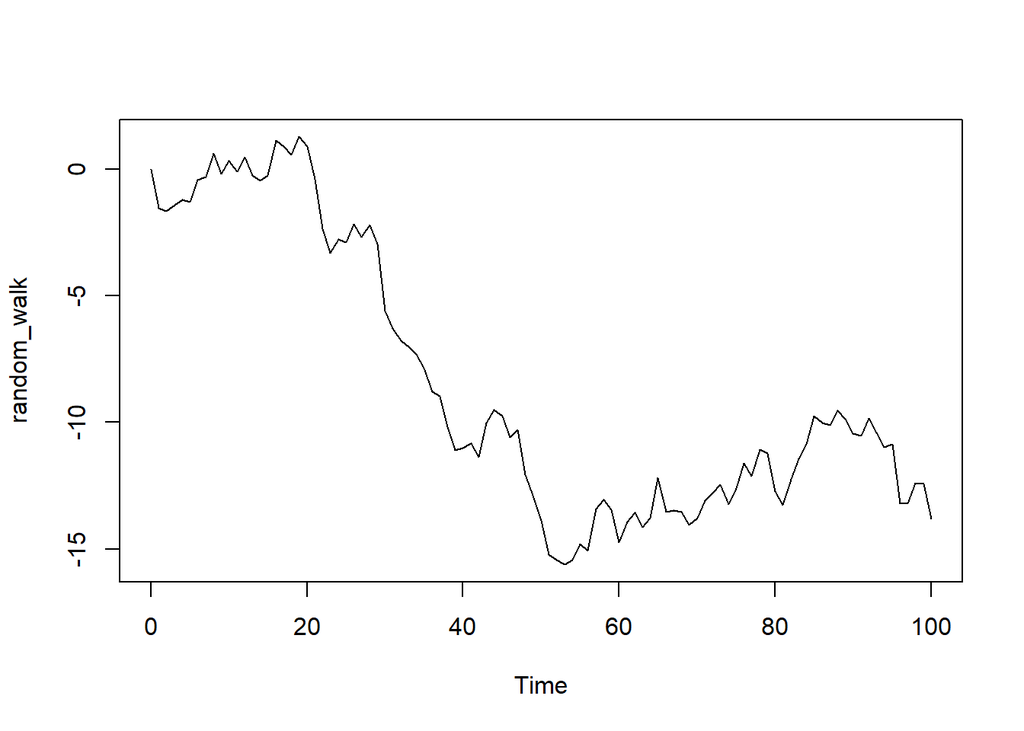

```r
# Generate a RW model using arima.sim
random_walk <- arima.sim(model = list(order = c(0, 1, 0)), n = 100)

# Plot random_walk
ts.plot(random_walk)
```

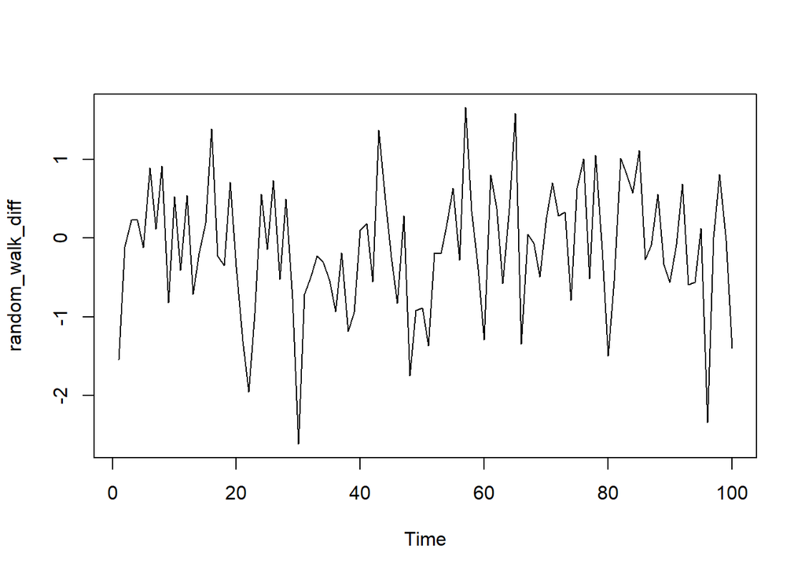

```r
# Calculate the first difference series
random_walk_diff <- diff(random_walk)

# Plot random_walk_diff
ts.plot(random_walk_diff)
```

As you can see, the first difference of your `random_walk` data is white noise data. This is because a random walk is simply recursive white noise data. By removing the long-term trend, you end up with simple white noise.

**Simulate the random walk model with a drift**

A random walk (RW) need not wander about zero, it can have an upward or downward trajectory, i.e., a drift or time trend. This is done by including an intercept in the RW model, which corresponds to the slope of the RW time trend.

For an alternative formulation, you can take the cumulative sum of a constant mean white noise (WN) series, such that the mean corresponds to the slope of the RW time trend.

To simulate data from the RW model with a drift you again use the `arima.sim()` function with the `model = list(order = c(0, 1, 0))` argument. This time, you should add the additional argument`mean = ...` to specify the drift variable, or the intercept.

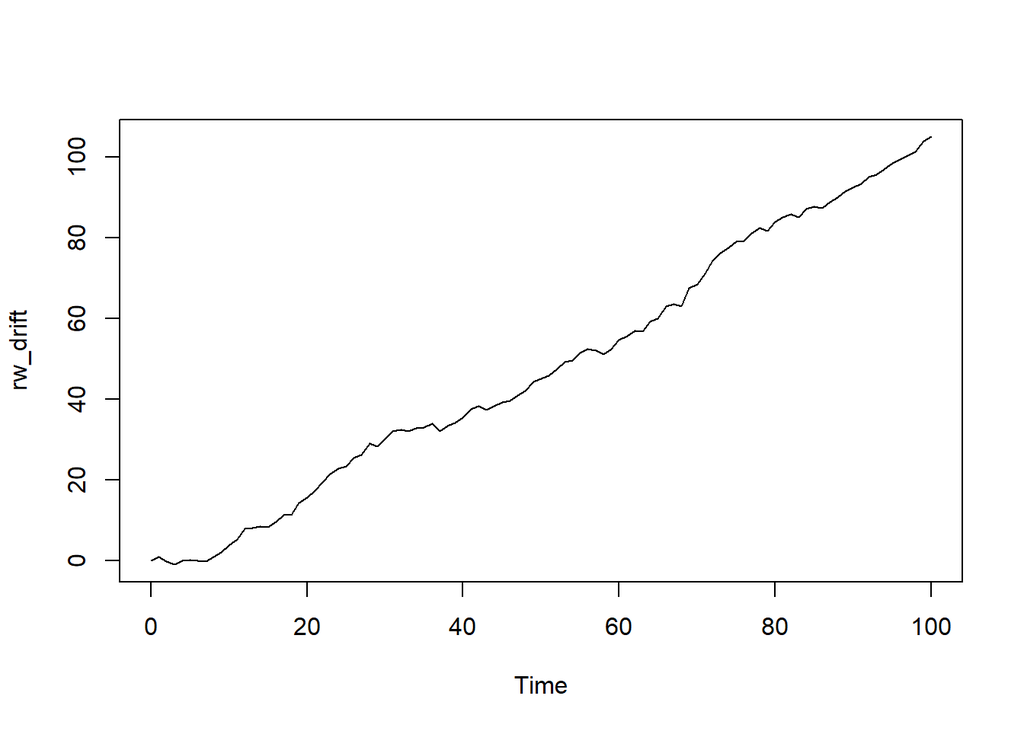

```r
# Generate a RW model with a drift uing arima.sim
rw_drift <- arima.sim(model = list(order = c(0, 1, 0)), n = 100, mean = 1)

# Plot rw_drift
ts.plot(rw_drift)
```

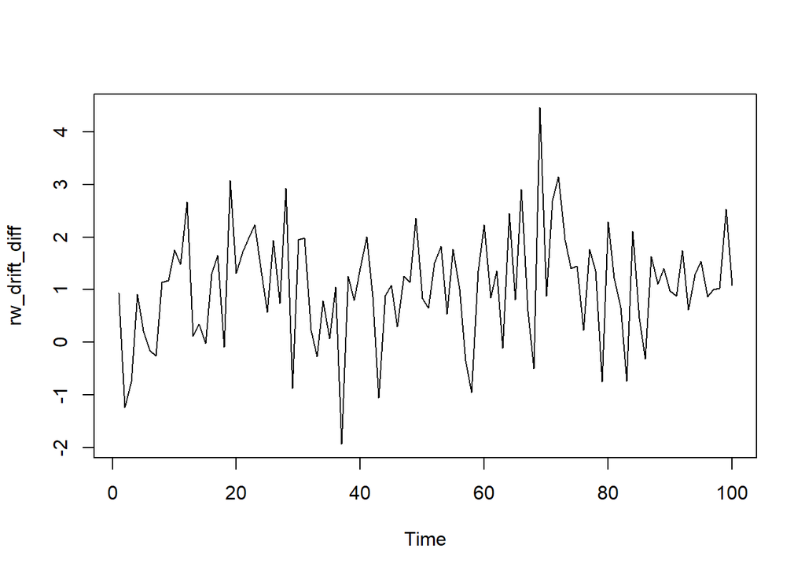

```r
# Calculate the first difference series
rw_drift_diff <- diff(rw_drift)

# Plot rw_drift_diff
ts.plot(rw_drift_diff)
```

Once again, taking the first difference of your random walk data transformed it back into white noise data, regardless of the presence of your long-term drift.

**Estimate the random walk model**

For a given time series `y` we can fit the random walk model with a drift by first differencing the data, then fitting the white noise (WN) model to the differenced data using the `arima()` command with the `order = c(0, 0, 0))` argument.

The `arima()` command displays information or output about the fitted model. Under the `Coefficients:` heading is the estimated drift variable, named the `intercept`. Its approximate standard error (or s.e.) is provided directly below it. The variance of the WN part of the model is also estimated under the label`sigma^2`.

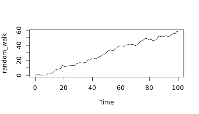

13.png

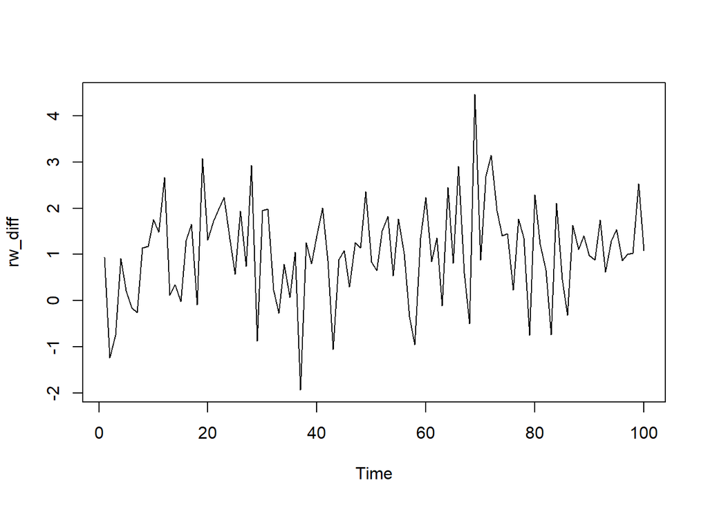

```r
# Difference your random_walk data
rw_diff <- diff(rw_drift)

# Plot rw_diff
ts.plot(rw_diff)
```

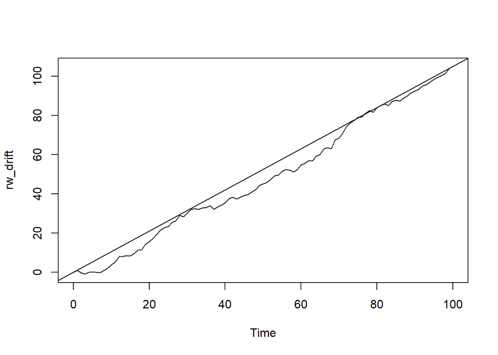

```r
# Now fit the WN model to the differenced data
model_wn <- arima(rw_diff, order = c(0, 0, 0))

# Copy and paste the value of the estimated time trend (intercept) below
int_wn <- model_wn$coef

# Plot the original random_walk data
ts.plot(rw_drift)

# Use abline(0, ...) to add time trend to the figure
abline(0, int_wn)
```

The `arima()` command correctly identified the time trend in your original random-walk data.

**Stationary processes**

- Stationarity
  - stationary models are parsimonious
  - stationary processes have distributional stability over time
- Observed time series:
  - fluctuate randomly
  - but behave similarly from one time period to the next
- Weak stationarity
  - mean, variance, covariance constant over time
  - $Y_1, Y_2, ...$ is a *weakly_stationary* process if:
    - Mean $\mu$ of $Y_t$ is same (constant) for all of $t$
    - Variance $\sigma^2$ of $Y_t$ is same (constant) for all of $t$
    - Covariance of $Y_t$ and $Y_s$ is same (constant) for all $|t - s| = h$ for all $h$
      - e.g., $Cov(Y_3, Y_7) = Cov(Y_7, Y_{11})$
  - estimate $\mu$ accurately by $\bar{y}$
- Stationarity: when?
  - many financial time series do not exhibit stationarity, however:
    - the **changes** in the series are often approximately stationary
    - a stationary series should show random oscillation around some fixed level; a phenomenon called **mean-reversion**

**Are the white noise model or the random walk model stationary?**

The white noise (WN) and random walk (RW) models are very closely related. However, only the RW is always non-stationary, both with and without a drift term. This is a simulation exercise to highlight the differences.

Recall that if we start with a mean zero WN process and compute its running or cumulative sum, the result is a RW process. The [cumsum()](https://www.rdocumentation.org/packages/base/versions/3.3.1/topics/cumsum) function will make this transformation for you. Similarly, if we create a WN process, but change its mean from zero, and then compute its cumulative sum, the result is a RW process with a drift.

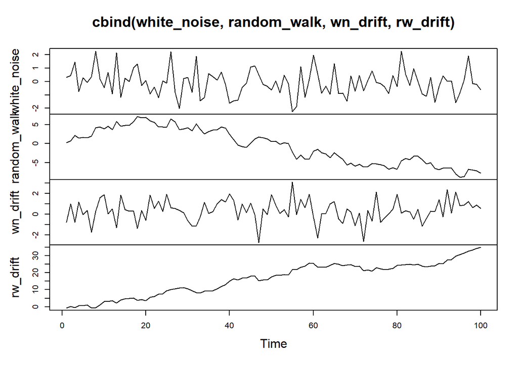

```r
# Use arima.sim() to generate WN data
white_noise <- arima.sim(model = list(order = c(0, 0, 0)), n = 100)

# Use cumsum() to convert your WN data to RW
random_walk <- cumsum(white_noise)

# Use arima.sim() to generate WN drift data
wn_drift <- arima.sim(model = list(order = c(0, 0, 0)), n = 100, mean = 0.4)

# Use cumsum() to convert your WN drift data to RW
rw_drift <- cumsum(wn_drift)

# Plot all four data objects
plot.ts(cbind(white_noise, random_walk, wn_drift, rw_drift))
```

As you can see, it is easy to reverse-engineer the RW data by simply generating a cumulative sum of white noise data.

**Scatterplots**

**Asset prices vs. asset returns**

The goal of investing is to make a profit. The revenue or loss from investing depends on the amount invested and changes in prices, and high revenue relative to the size of an investment is of central interest. This is what financial asset returns measure, changes in price as a fraction of the initial price over a given time horizon, for example, one business day.

Let’s again consider the `eu_stocks` dataset. This dataset reports index values, which we can regard as prices. The indices are not investable assets themselves, but there are many investable financial assets that closely track major market indices, including mutual funds and exchange traded funds.